# 2D Wave field modelling

1. Polar coordinates DFT Full: We define the Wave spectrum on a polar mesh (r, theta) and create the wave witth the "DFTpolar" wave_construction method
2. Polar coordinates DFT Selection: We define the Wave spectrum on a polar mesh (r, theta) and create the wave witth the "DFTpolar" wave_construction method with a reduction of wave nodes by using an EqualEnergyBins algorithm
3. Cartesian coordinates FFT Full: We define the Wave spectrum on a cartesian mesh (k_x, k_y)and then use the FFT or DFTcartesian wave_construction method
4. Comparing Calculation times: Compare the calculation time for the three methods above

### 2D Wave using a polar mesh

The spectrum defined in polar mesh simply multiplies the 1D frequency distribution $S(\omega)$ with the directional distribution function $D(\theta)$. In theory, the diretional distribution may be a function of the frequency as well, however, that is not implemented and left out of consideration. The frequency distribution is created using the Wave1D class. The resulting object is passed as an parameter to the Wave2D class. It looks like this

First start with the import of our modules required to run this notebook example

```python
import sys
import os
import logging
import numpy as np
import matplotlib.pyplot as plt
import numpy as np
from IPython.display import HTML

from hmc_utils.misc import (create_logger, Timer)
import hmc_marine.wave_fields as wf
import hmc_marine

logger = create_logger(console_log_format_clean=True, console_log_level=logging.INFO)
```

To model a 2D wave you first have to set up 1D wave to obtain the spectral distribution. We have seen this in the *example_wave_modelling* notebook already.

```python
wave1D_1 = wf.Wave1D(n_kx_nodes=128, nx_points=251, Lx=500, wave_construction="DFTpolar",
                     Tp=8, spectrum_type="jonswap", Hs=3, spectral_version="hmc",wave_selection="All")
wave1D_1.make_report()
```

```
Initialise jonswap 1D wave field
kx_max larger than nyquist belongin to dx=2.0: clipping kx to 1.5707963267948966
Name                                     : wave_jonswap_DFTpolar_All_1d
----------- Domain settings --------
Start x [m]                              : 0
End x [m]                                : 500
Length x [m]                             : 500
----------- Time settings --------
Start t [s]                              : 0
End t [s]                                : 1000000
Length t [s]                             : 1000000
Delta t [s]                              : 1.0
----------- Numerical resolutions --------
Number x - nodes                         : 251
Number kx - nodes                        : 128
Delta x [m]                              : 2.0
Delta kx min [rad/m]                     : 0.012368475014132851
Delta kx max [rad/m]                     : 0.012368475014133073
Delta kx first [rad/m]                   : 0.012368475014133044
k-min [rad/m]                            : 0.0
k-max [rad/m]                            : 1.5707963267948966
k-nyq [rad/m]                            : 1.5707963267948966
L_max [m]                                : 508.0
----------- Numerical methodds --------
Selection method                         : All
Construction method                      : DFTpolar
```

We took 128 nodes in the wave vector domain. Let's have a look at the spectrum to see if this is enough to resolve the peak in the Jonswap spectrum

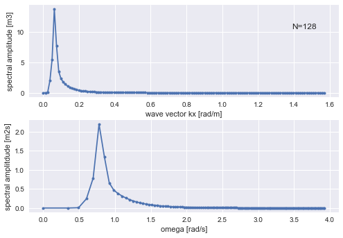

```python
wave1D_1.plot_spectrum()
plt.show()
```

```python
wave1D_1.reset_time(nt_samples=500, delta_t=.1)
movie = wave1D_1.animate_wave()
HTML(movie.to_html5_video())
```

[video not shown]

```python
plt.gcf().clear()
```

Using this 1D wave as a startig point we can now construct the 2D wave. We set the wave direction to 215 degrees. Please note that you have to convert the direction to radians first. If the *DFT_polar* mode is used (which was set in the Wave1D object), the 2D wave spectrum is constructed from the 1D spectrum vs k obtained from the wave1D and a directional distirbution. This means that also the resolution settings of the wave1D were all maintained. Only for the number of points in the x- and y-direction we have to specify a new value again (which, to emphasis again, may be different from the number of nodes in k-space since we use DFT). Also the resolution in the theta-direction in the spectrum needs to be defined, which we put on 60.

```python
  with Timer(message="DFT polar") as t:
        wave2D_1 = wf.Wave2D(wave1D=wave1D_1,
                             nx_points=128, ny_points=128,
                             Lx=500, Ly=500,
                             n_theta_nodes=60,
                             Theta_0=np.deg2rad(215),
                             Theta_s_spreading_factor=5,
                             )
wave2D_1.make_report()
```

```
Initialise JonSwap 1D wave field
DFT polar            routine              :       9942 ms
Name                                     : wave_jonswap_DFTpolar_All_2d
----------- Domain settings --------
Start x [m]                              : 0
Start y [m]                              : 0
End x [m]                                : 500
End y [m]                                : 500
Length x [m]                             : 500
Length y [m]                             : 500
----------- Time settings --------
Start t [s]                              : 0
End t [s]                                : 50.0
Length t [s]                             : 50.0
Delta t [s]                              : 0.1
----------- Numerical resolutions --------
Number x - nodes                         : 128
Number y - nodes                         : 128
Total number of spatial points           : 16384
# Polar mesh specifications
Number k_r - nodes                       : 128
Number theta - nodes                     : 60
Number total nodes                       : 7680
----------- Numerical methods --------
Selection method                         : All
Construction method                      : DFTpolar
DFT N x N                                : 125829120
FFT N x log(N)                           : 158991.327688118
```

Let's plot the spectrum of our wave field

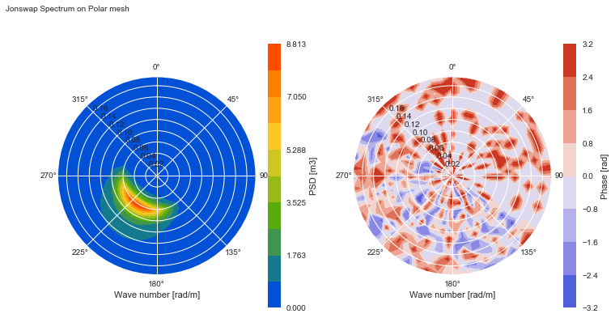

```python
wave2D_1.plot_spectrum(plot_title="Jonswap Spectrum on Polar mesh", polar_projection=True,
                       use_contourf=True, shift_origin=False, r_axis_lim=(0, 0.175), r_label_position=315,
                               )
plt.show()
```

Let's have a look at the animated wave field.

```python
wave1D_1.reset_time(nt_samples=20, delta_t=1)
movie = wave2D_1.animate_wave(plot_title="Jonswap Wave constructed with DFT on Polar Spectrum",
                              use_contourf=True, min_data_value=-2, max_data_value=2, interval=400)
HTML(movie.to_html5_video())
```

[video not shown]

```python
plt.gcf().clear()
```

We limitted ourself to 20 frames for the animation, otherwise it would take too long: a DFT with all 128 x 128 = 16384 nodes takes about 9 seconds per frame calculation. We can significantly reduce the number of wave vector nodes by taking the EqualEnergyBins settings. With the EqualEnergyBins the total energy of each bin will be the same, which will result in more narrow bin width around the peak of the spectrum. Also we set the flag *use_subrange_energy_limits*, which will clip all the spectral components as defined by the *Subrange* method (have a look at the *examle_wave_field_modelling* notebook for an example on a 1D wave). Now let's simulate the wave again

```python
wave1D_2 = wf.Wave1D(n_kx_nodes=64, nx_points=251, Lx=500, wave_construction="DFTpolar", n_bins_equal_energy=32,
                     Tp=8, spectrum_type="jonswap", Hs=3, spectral_version="hmc",wave_selection="EqualEnergyBins",
                    use_subrange_energy_limits=True)
wave1D_2.make_report()
```

```
Initialise jonswap 1D wave field
kx_max larger than nyquist belongin to dx=2.0: clipping kx to 1.5707963267948966
Name                                     : wave_jonswap_DFTpolar_EqualEnergyBins_1d
----------- Domain settings --------
Start x [m]                              : 0
End x [m]                                : 500
Length x [m]                             : 500
----------- Time settings --------
Start t [s]                              : 0
End t [s]                                : 1000000
Length t [s]                             : 1000000
Delta t [s]                              : 1.0
----------- Numerical resolutions --------
Number x - nodes                         : 251
Number kx - nodes                        : 29
Delta x [m]                              : 2.0
Delta kx min [rad/m]                     : 0.001137212605196225
Delta kx max [rad/m]                     : 0.018088887024095307
Delta kx first [rad/m]                   : 0.024933275028490423
k-min [rad/m]                            : 0.049866550056980846
k-max [rad/m]                            : 0.15911623387244875
k-nyq [rad/m]                            : 1.5707963267948966
L_max [m]                                : 2558.9670281622657
----------- Numerical methodds --------
Selection method                         : EqualEnergyBins
Construction method                      : DFTpolar
```

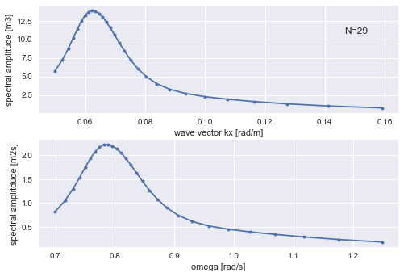

```python
wave1D_2.plot_spectrum()
plt.show()
```

Compared to the full spectum of our first attempt were we used 128 wave vector nodes for the spectrum, with only 29 nodes we have a much better description of the peak in the spectrum due the higher density of nodes in this region. Using this spectral distribution we can now create a 2D spectrum:

```python
with Timer(message="DFT polar EqualEnergyBins") as t:
    wave2D_2 = wf.Wave2D(wave1D=wave1D_2,
                         Lx=500, Ly=500,
                         n_theta_nodes=60,
                         Theta_0=np.deg2rad(215),
                         Theta_s_spreading_factor=5,
                         )
wave2D_2.make_report()
```

```
Initialise JonSwap 1D wave field
DFT polar EqualEnergyBins routine              :        263 ms
Name                                     : wave_jonswap_DFTpolar_EqualEnergyBins_2d
----------- Domain settings --------
Start x [m]                              : 0
Start y [m]                              : 0
End x [m]                                : 500
End y [m]                                : 500
Length x [m]                             : 500
Length y [m]                             : 500
----------- Time settings --------
Start t [s]                              : 0
End t [s]                                : 1000000
Length t [s]                             : 1000000
Delta t [s]                              : 1.0
----------- Numerical resolutions --------
Number x - nodes                         : 64
Number y - nodes                         : 64
Total number of spatial points           : 4096
# Polar mesh specifications
Number k_r - nodes                       : 29
Number theta - nodes                     : 27
Number total nodes                       : 783
----------- Numerical methods --------
Selection method                         : EqualEnergyBins
Construction method                      : DFTpolar
DFT N x N                                : 3207168
FFT N x log(N)                           : 34069.57021888243
```

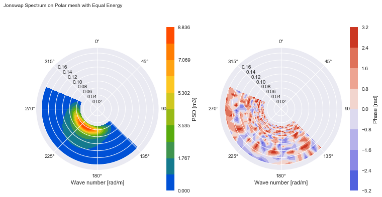

```python
wave2D_2.plot_spectrum(plot_title="Jonswap Spectrum on Polar mesh with Equal Energy", polar_projection=True,
                       use_contourf=True, shift_origin=False,r_axis_lim=(0, 0.175), r_label_position=315
                               )
plt.show()
```

The spectrum now only has the wave nodes around the peak. Also a selection in the circumferential direction was made. As a result, to total amount of wave numbers in the 2D spectrum is now n_k_r_nodes x n_theta_nodes = 29 x 27 = 783, compared to 7680 nodes in our first attempt. If we animate the frames we can compare the wave fields as well:

```python
wave1D_2.reset_time(nt_samples=20, delta_t=1)
movie2 = wave2D_2.animate_wave(plot_title="Jonswap Wave constructed with DFT on Polar Spectrum with EqualEnergyBins",
                              use_contourf=True, min_data_value=-2, max_data_value=2, interval=400)
HTML(movie2.to_html5_video())
```

[video not shown]

```python
plt.gcf().clear()
```

The wave fields look very similar in its large scale structures, although of course the spectrum with the node selection is smoother and has a slightly lower Hs estimate from the wave height standard deviation. This is the price we pay for a speed up of simulation time of more than a factor 20.

#### 2D wave simulation with using a FFT

Finally it is demonstrated how we achieve the same speed up factor as the *EqualEnergyBins* method without reducing the number of wave nodes by using an FFT spectrum in stead of a DFT. Let's again first define the one-dimensional wave:

```python
wave1D_3 = wf.Wave1D(n_kx_nodes=128, nx_points=251, Lx=500, wave_construction="FFT",
                     Tp=8, spectrum_type="jonswap", Hs=3, spectral_version="hmc",wave_selection="All")
wave1D_3.make_report()
```

```
Initialise jonswap 1D wave field
Name                                     : wave_jonswap_FFT_All_1d
----------- Domain settings --------
Start x [m]                              : 0
End x [m]                                : 500
Length x [m]                             : 500
----------- Time settings --------
Start t [s]                              : 0
End t [s]                                : 1000000
Length t [s]                             : 1000000
Delta t [s]                              : 1.0
----------- Numerical resolutions --------
Number x - nodes                         : 251
Number kx - nodes                        : 251
Delta x [m]                              : 2.0
Delta kx min [rad/m]                     : -3.129076348197005
Delta kx max [rad/m]                     : 0.012516305392788363
Delta kx first [rad/m]                   : 0.012516305392788021
k-min [rad/m]                            : -1.5645381740985025
k-max [rad/m]                            : 1.5645381740985025
k-nyq [rad/m]                            : 1.5707963267948966
L_max [m]                                : 502.0
----------- Numerical methodds --------
Selection method                         : All
Construction method                      : FFT
```

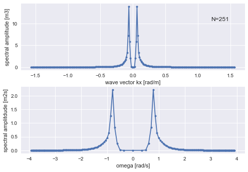

```python
wave1D_3.plot_spectrum()
plt.show()
```

Since the 'FFT' *wave_construction* method was selected we now have created a spectrum symmetric around k=0. Based on this we can create the 2D wave using the 1D wave as an input. It it important to realise that this time the number of nodes in the x-domain is the same as in the k-domain. Also this time a Cartesian description of the 2D mesh is made instead of a polar description, which means that the number of nodes of the 2D wave is not based on the number of nodes of the 1D wave, but need to be redefined.Since for FFT the number of kx and ky nodes in wave vector domain are the same as the number of nx and ny nodes in spatial domain, we only define the mesh in spatial domain; the mesh in k-domain follows from that

```python
with Timer(message="FFT mesh") as t:
    wave2D_3 = wf.Wave2D(wave1D=wave1D_3,
                         nx_points=128, ny_points=128,
                         Lx=500, Ly=500,
                         Theta_0=np.deg2rad(215),
                         Theta_s_spreading_factor=5,
                         )
wave2D_3.make_report()
```

```
Initialise JonSwap 1D wave field
FFT mesh             routine              :       2060 ms
Name                                     : wave_jonswap_FFT_All_2d
----------- Domain settings --------
Start x [m]                              : 0
Start y [m]                              : 0
End x [m]                                : 500
End y [m]                                : 500
Length x [m]                             : 500
Length y [m]                             : 500
----------- Time settings --------
Start t [s]                              : 0
End t [s]                                : 1000000
Length t [s]                             : 1000000
Delta t [s]                              : 1.0
----------- Numerical resolutions --------
Number x - nodes                         : 128
Number y - nodes                         : 128
Total number of spatial points           : 16384
# Cartesian mesh specifications
Number kx - nodes                        : 128
Number ky - nodes                        : 128
Delta x [m]                              : 3.937007874015748
Delta y [m]                              : 3.937007874015748
Delta kx min [rad/m]                     : -1.5834608721796803
Delta ky min [rad/m]                     : -1.5834608721796803
Delta kx max [rad/m]                     : 0.01246819584393466
Delta ky max [rad/m]                     : 0.01246819584393466
Delta kx first [rad/m]                   : 0.012468195843934491
Delta ky first [rad/m]                   : 0.012468195843934491
kx-min [rad/m]                           : -0.7979645340118074
ky-min [rad/m]                           : -0.7979645340118074
kx-max [rad/m]                           : 0.7854963381678729
ky-max [rad/m]                           : 0.7854963381678729
kx-nyq [rad/m]                           : 0.7979645340118074
ky-nyq [rad/m]                           : 0.7979645340118074
Lx_max [m]                               : 503.93700787401576
Ly_max [m]                               : 503.93700787401576
----------- Numerical methods --------
Selection method                         : All
Construction method                      : FFT
DFT N x N                                : 268435456
FFT N x log(N)                           : 158991.327688118
```

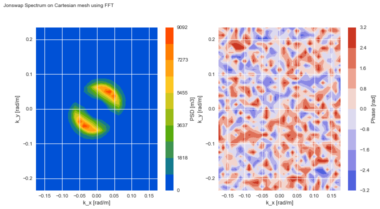

```python
wave2D_3.plot_spectrum(plot_title="Jonswap Spectrum on Cartesian mesh using FFT", polar_projection=False,
                       use_contourf=True, shift_origin=True,r_axis_lim=(0, 0.175), r_label_position=315,
                       kx_min=-0.175, kx_max=0.175, ky_min=-0.175, ky_max=0.175
                               )
plt.show()
```

```python
wave1D_3.reset_time(nt_samples=20, delta_t=1)
movie3 = wave2D_3.animate_wave(plot_title="Jonswap Wave constructed with FFT based on all nodes",
                              use_contourf=True, min_data_value=-2, max_data_value=2, interval=400)
HTML(movie3.to_html5_video())
```

[video not shown]

```python
plt.gcf().clear()
```

##### Comparing the calculation times

```python
wave1D_1.reset_time(nt_samples=10)
with Timer(message="Total time {}".format(wave2D_2.name)) as t:
    while wave1D_1.time < wave1D_1.t_end:
        with Timer(message="DFT 1 at t={:2d}. Hs = {:.2f} m".format(wave1D_1.time, 4 * wave2D_1.amplitude.std())) as t2:
            wave2D_1.propagate_wave()
```

```
DFT 1 at t= 0. Hs = 3.06 m routine              :       8968 ms
DFT 1 at t= 1. Hs = 3.12 m routine              :       8881 ms
DFT 1 at t= 2. Hs = 3.13 m routine              :       9338 ms
DFT 1 at t= 3. Hs = 3.13 m routine              :       8706 ms
DFT 1 at t= 4. Hs = 3.11 m routine              :       9311 ms
DFT 1 at t= 5. Hs = 3.11 m routine              :       9356 ms
DFT 1 at t= 6. Hs = 3.13 m routine              :       8766 ms
DFT 1 at t= 7. Hs = 3.12 m routine              :       8831 ms
DFT 1 at t= 8. Hs = 3.10 m routine              :       9243 ms
DFT 1 at t= 9. Hs = 3.11 m routine              :       8461 ms
Total time wave_jonswap_DFTpolar_EqualEnergyBins_2d routine              :      89870 ms
```

```python
wave1D_2.reset_time(nt_samples=10)
with Timer(message="Total time {}".format(wave2D_2.name)) as t:
    while wave1D_2.time < wave1D_2.t_end:
        with Timer(message="DFT 2 at t={:2d}. Hs = {:.2f} m".format(wave1D_2.time, 4 * wave2D_2.amplitude.std())) as t2:
            wave2D_2.propagate_wave()
```

```
DFT 2 at t= 0. Hs = 2.83 m routine              :        245 ms
DFT 2 at t= 1. Hs = 2.90 m routine              :        233 ms
DFT 2 at t= 2. Hs = 2.92 m routine              :        233 ms
DFT 2 at t= 3. Hs = 2.92 m routine              :        233 ms
DFT 2 at t= 4. Hs = 2.92 m routine              :        235 ms
DFT 2 at t= 5. Hs = 2.92 m routine              :        223 ms
DFT 2 at t= 6. Hs = 2.93 m routine              :        230 ms
DFT 2 at t= 7. Hs = 2.93 m routine              :        228 ms
DFT 2 at t= 8. Hs = 2.92 m routine              :        223 ms
DFT 2 at t= 9. Hs = 2.92 m routine              :        230 ms
Total time wave_jonswap_DFTpolar_EqualEnergyBins_2d routine              :       2310 ms
```

```python
wave1D_3.reset_time(nt_samples=10)
with Timer(message="Total time {}".format(wave2D_3.name)) as t:
    while wave1D_3.time < wave1D_3.t_end:
        with Timer(message="FFT at t={:2d}. Hs = {:.2f} m".format(wave1D_3.time, 4 * wave2D_3.amplitude.std())) as t2:
            wave2D_3.propagate_wave()
```

```
FFT at t= 0. Hs = 2.99 m routine              :          0 ms
FFT at t= 1. Hs = 2.99 m routine              :          0 ms
FFT at t= 2. Hs = 2.99 m routine              :          3 ms
FFT at t= 3. Hs = 2.99 m routine              :          0 ms
FFT at t= 4. Hs = 2.99 m routine              :          3 ms
FFT at t= 5. Hs = 2.99 m routine              :          5 ms
FFT at t= 6. Hs = 2.99 m routine              :          3 ms
FFT at t= 7. Hs = 2.99 m routine              :          8 ms
FFT at t= 8. Hs = 2.99 m routine              :         13 ms
FFT at t= 9. Hs = 2.99 m routine              :          0 ms
Total time wave_jonswap_FFT_All_2d routine              :         58 ms
```